# Report of Kaggle Question Practice- Titanic

Li Cheng-En

7/27/2018

### Motivation

As a student who stayed in the department of finance, statistic is important to me. Furthermore, the issue of big data was popular, it also highlights the importance of statistic. R is a good tool to do the works of statistic, so I want to learn some knowledge about R to strengthen myself.

In order to prove my capability, I want to use R to analyze an issue. Hence, I chose “Titanic”, a question of Kaggle, a popular website about machine learning in the US, as the target question. This file is my final answer & report of the Kaggle question I chose.

I divided my report into two part. I would analyze the property of each variable in the first part, and I do some prediction in the second part. Please read my complete report to understand the process of my analysis.

I also have written several codes of R. For more details about my codes, please see https://github.com/Datoto1205/R-Practice.

### Observation

##### 1. Raw Data

```r
rawDataOfTitanic <- read.csv("/Users/Lizhengen/Documents/GitHub/R-Practice/Data of Titanic/train.csv")

# Delete the Null Data
complete.cases(rawDataOfTitanic)
rawDataOfTitanicWithoutNull <- na.omit(rawDataOfTitanic)
summary(rawDataOfTitanicWithoutNull)

# Delete the Null Data
complete.cases(rawDataOfTitanic)
rawDataOfTitanicWithoutNull <- na.omit(rawDataOfTitanic)
summary(rawDataOfTitanicWithoutNull)
```

I use the codes above to import the raw data, check whether there is any null data and get its summary. I found that some raw data are null. It seems that I need to use some method to replace these data. However, I wonder whether the new data is useful or not. Therefore, I decided to delete all of the raws in which there are some null data. The summary of the final data was shown below.

```
##   PassengerId       Survived          Pclass
##  Min.   :  1.0   Min.   :0.0000   Min.   :1.000
##  1st Qu.:222.2   1st Qu.:0.0000   1st Qu.:1.000
##  Median :445.0   Median :0.0000   Median :2.000
##  Mean   :448.6   Mean   :0.4062   Mean   :2.237
##  3rd Qu.:677.8   3rd Qu.:1.0000   3rd Qu.:3.000
##  Max.   :891.0   Max.   :1.0000   Max.   :3.000
##
##                                     Name         Sex           Age
##  Abbing, Mr. Anthony                  :  1   female:261   Min.   : 0.42
##  Abbott, Mr. Rossmore Edward          :  1   male  :453   1st Qu.:20.12
##  Abbott, Mrs. Stanton (Rosa Hunt)     :  1                Median :28.00
##  Abelson, Mr. Samuel                  :  1                Mean   :29.70
##  Abelson, Mrs. Samuel (Hannah Wizosky):  1                3rd Qu.:38.00
##  Adahl, Mr. Mauritz Nils Martin       :  1                Max.   :80.00
##  (Other)                              :708
##      SibSp            Parch                 Ticket         Fare
##  Min.   :0.0000   Min.   :0.0000   347082      :  7   Min.   :  0.00
##  1st Qu.:0.0000   1st Qu.:0.0000   3101295     :  6   1st Qu.:  8.05
##  Median :0.0000   Median :0.0000   347088      :  6   Median : 15.74
##  Mean   :0.5126   Mean   :0.4314   CA 2144     :  6   Mean   : 34.69
##  3rd Qu.:1.0000   3rd Qu.:1.0000   382652      :  5   3rd Qu.: 33.38
##  Max.   :5.0000   Max.   :6.0000   S.O.C. 14879:  5   Max.   :512.33
##                                    (Other)     :679
##          Cabin     Embarked
##             :529    :  2
##  B96 B98    :  4   C:130
##  C23 C25 C27:  4   Q: 28
##  G6         :  4   S:554
##  C22 C26    :  3
##  D          :  3
##  (Other)    :167
```

##### 2. Survival Rate

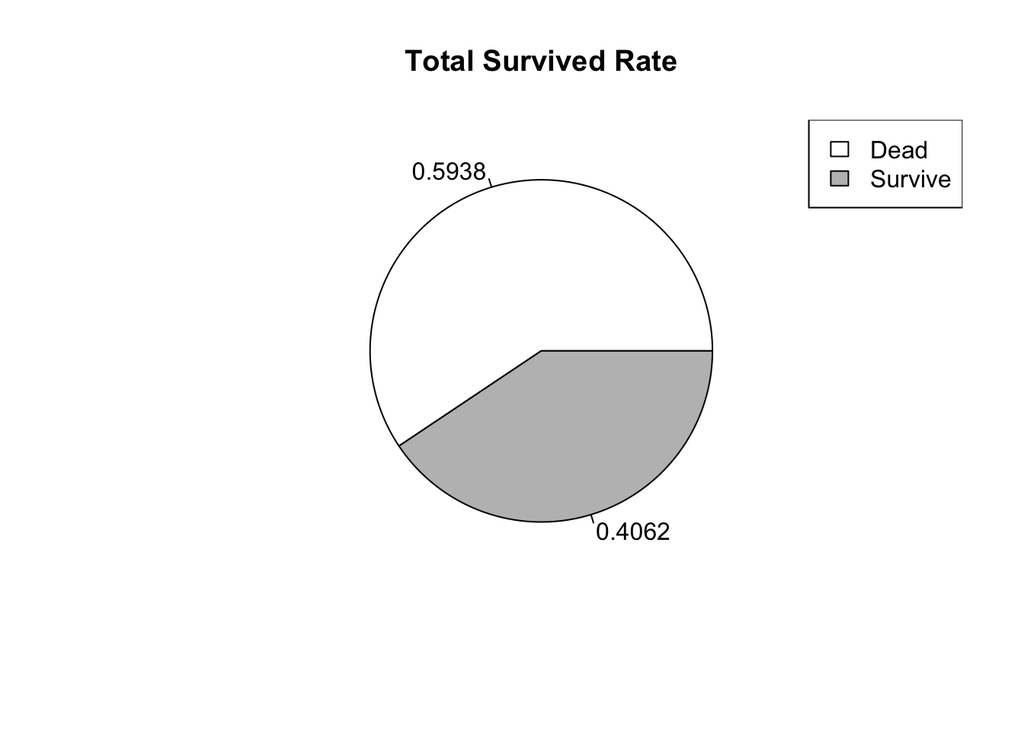

```r
# Survival Rate
tableOfSurviveData <- table(rawDataOfTitanicWithoutNull$Survived)
names(tableOfSurviveData) <- c("Dead", "Survive")

TotalNumberOfPeople <- tableOfSurviveData[1]+tableOfSurviveData[2]
percentageLabel <- c(round(tableOfSurviveData[1]/TotalNumberOfPeople, 4), round(tableOfSurviveData[2]/TotalNumberOfPeople, 4))

colorOfPieChart <- c("white", "gray")
pie(tableOfSurviveData, labels = percentageLabel, col = colorOfPieChart, main = "Total Survived Rate", radius = 0.8)

legend("topright", names(tableOfSurviveData), fill = colorOfPieChart)
```

After I disposed of null data in the raw data, I started to examine it through each variable. The foremost variable is survival rate. I used the codes above to check it, and I found that the people who survived in this accident account for around 41 percent of all the people who took the Titanic. The pie chart above reflected this result.

##### 3. Pclass

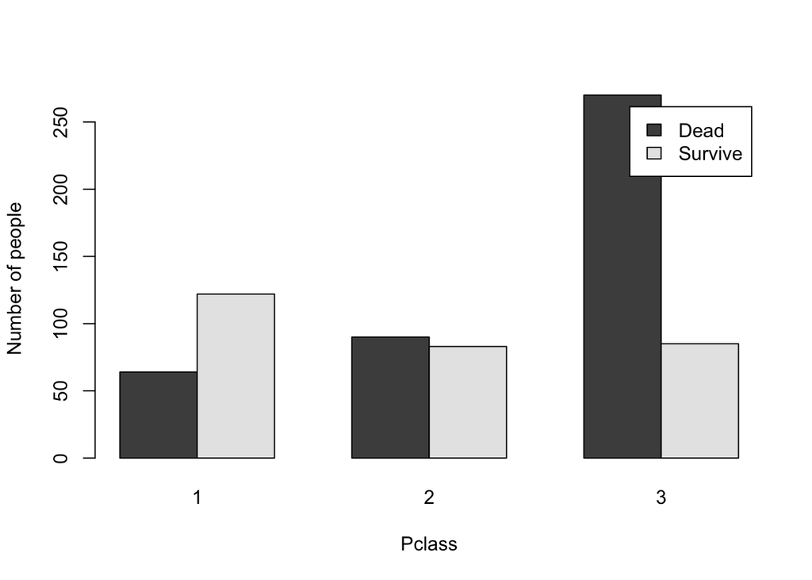

```r
# Pclass
tableOfNumberOfSurvivedAndPclass <- table(rawDataOfTitanicWithoutNull$Survived, rawDataOfTitanicWithoutNull$Pclass)
barplot(tableOfNumberOfSurvivedAndPclass, beside = T, legend.text = c("Dead", "Survive"), xlab = "Pclass", ylab = "Number of people")
```

##### 4. Sex

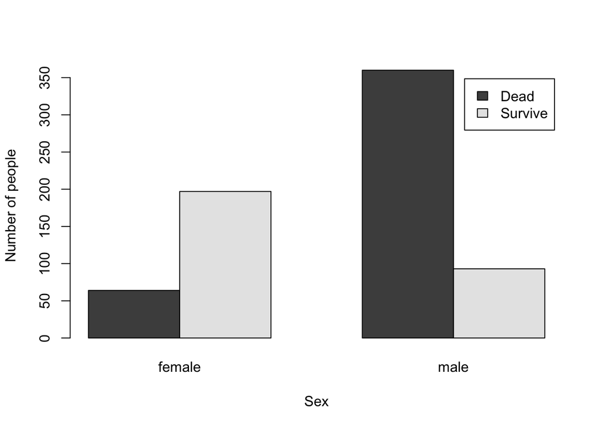

```r
# Sex
tableOfNumberOfSurvivedAndSex <- table(rawDataOfTitanicWithoutNull$Survived, rawDataOfTitanicWithoutNull$Sex)
barplot(tableOfNumberOfSurvivedAndSex, beside = T, legend.text = c("Dead", "Survive"), xlab = "Sex", ylab = "Number of people")
```

The second variable is sex, which means the sex of each passenger. After we ran the codes above and saw the bar chart, we could found that female passenger could survive more possibly. The bar plot above reflected this result.

##### 5. Age

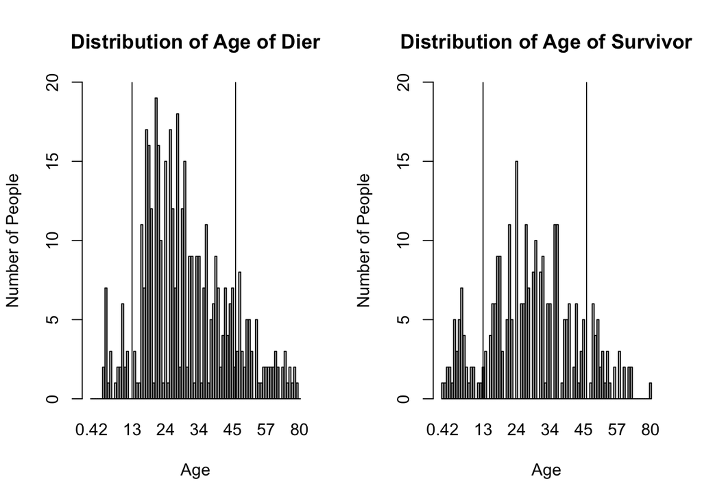

```r
# Age
tableOfNumberOfSurvivedAndAge <- table(rawDataOfTitanicWithoutNull$Age, rawDataOfTitanicWithoutNull$Survived)

par(mfrow = c(1, 2))
barplot(tableOfNumberOfSurvivedAndAge[,1], main = "Distribution of Age of Dier", xlab = "Age", ylab = "Number of People", ylim = c(0, 20))
abline(v = 21)
abline(v = 73)

barplot(tableOfNumberOfSurvivedAndAge[,2], main = "Distribution of Age of Survivor", xlab = "Age", ylab = "Number of People", ylim = c(0, 20))
abline(v = 21)
abline(v = 73)
```

The third variable is age, which means the age of each passenger. After we ran the codes above, we could found that the younger could survive more possibly, and the older could survive less possibly. The number of middle-aged passengers who survived was less than that of passengers who died. The plots of the distribution of age were shown above.

##### 6. Distribution of Number of Sibling and Spouse

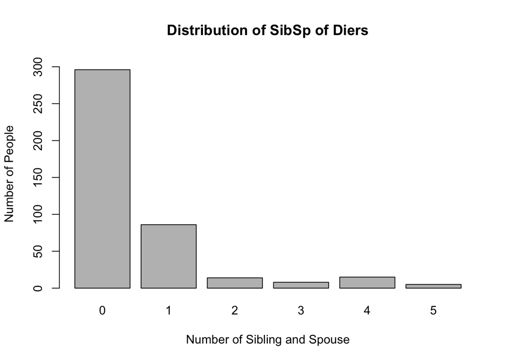

```r
# Distribution of Number of Sibling and Spouse
tableOfNumberOfSurvivedAndSibSp <- table(rawDataOfTitanicWithoutNull$SibSp, rawDataOfTitanicWithoutNull$Survived)
barplot(tableOfNumberOfSurvivedAndSibSp[,1], beside = T, main = "Distribution of SibSp of Diers", ylim = c(0, 310), xlab = "Number of Sibling and Spouse", ylab = "Number of People")
```

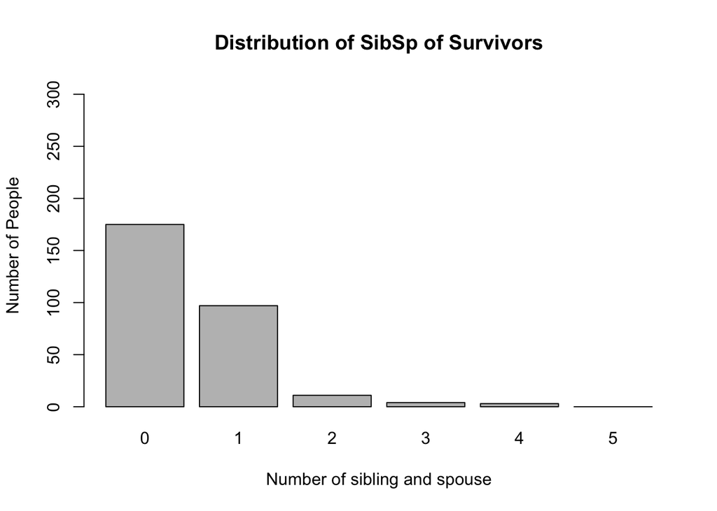

```r
barplot(tableOfNumberOfSurvivedAndSibSp[,2], beside = T, main = "Distribution of SibSp of Survivors", ylim = c(0, 310), xlab = "Number of sibling and spouse", ylab = "Number of People")
```

The fourth variable is SibSp, which means the distribution of the number of sibling and spouse (called SibSp below). After we ran the codes above, we could found that the survivor who owns one SibSp could survive more possibly relatively. The bar plots of the distribution of SibSp were shown above.

##### 7. Distribution of Number of Parents and Descendant

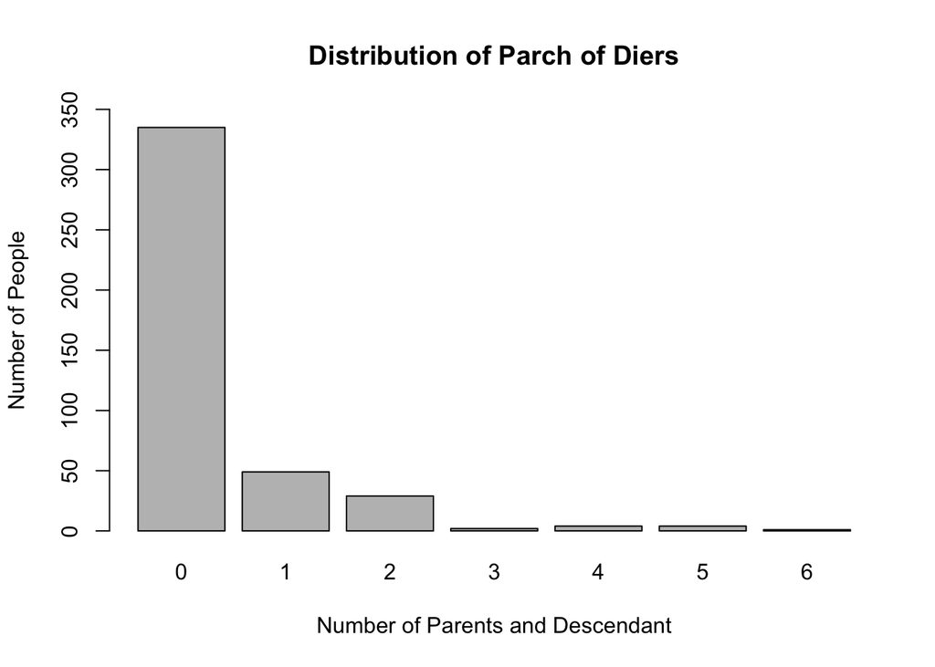

```r
# Distribution of Number of Parents and Descendant
tableOfNumberOfSurvivedAndParch <- table(rawDataOfTitanicWithoutNull$Parch, rawDataOfTitanicWithoutNull$Survived)
barplot(tableOfNumberOfSurvivedAndParch[, 1], beside = T, main = "Distribution of Parch of Diers", ylim = c(0, 350), xlab = "Number of Parents and Descendant", ylab = "Number of People")
```

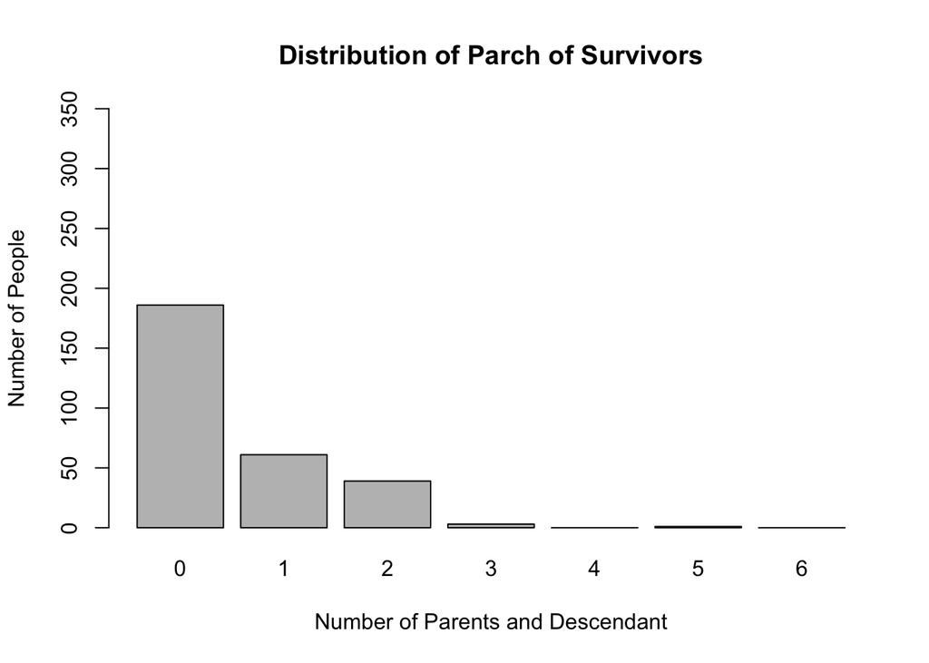

```r
barplot(tableOfNumberOfSurvivedAndParch[, 2], beside = T, main = "Distribution of Parch of Survivors", ylim = c(0, 350), xlab = "Number of Parents and Descendant", ylab = "Number of People")
```

The fifth variable is Parch, which means the distribution of the number of parents and descendant (called Parch below). After we ran the codes above, we could found that the survivor who own one and two Parch could survive more possibly relatively. The bar plots of the distribution of Parch were shown above.

##### 8. Fares

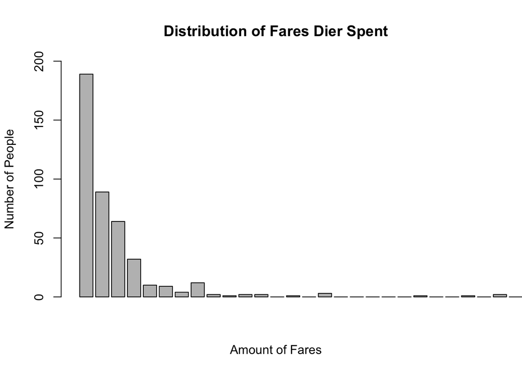

```r
vectorOfTimesOfDistributionOfDier <- c(rep(0, 30))
vectorOfTimesOfDistributionOfSurvivor <- c(rep(0, 30))

for (i in 1:30) {
  for (j in 1:nrow(rawDataOfTitanicWithoutNull)) {
    if ((rawDataOfTitanicWithoutNull$Survived[j] == 0) &&
        (10 * (i - 1) <= rawDataOfTitanicWithoutNull$Fare[j]) &&
        (rawDataOfTitanicWithoutNull$Fare[j] < (10 * i))) {
      vectorOfTimesOfDistributionOfDier[i] = vectorOfTimesOfDistributionOfDier[i] + 1
    } else if ((rawDataOfTitanicWithoutNull$Survived[j] == 1) &&
               (10 * (i - 1) <= rawDataOfTitanicWithoutNull$Fare[j]) &&
               (rawDataOfTitanicWithoutNull$Fare[j] < (10 * i))) {
      vectorOfTimesOfDistributionOfSurvivor[i] = vectorOfTimesOfDistributionOfSurvivor[i] + 1
    } else {

    }
  }
}

barplot(vectorOfTimesOfDistributionOfDier, xlim = c(0, 30), ylim = c(0, 200), main = "Distribution of Fares Dier Spent", xlab = "Amount of Fares", ylab = "Number of People")
```

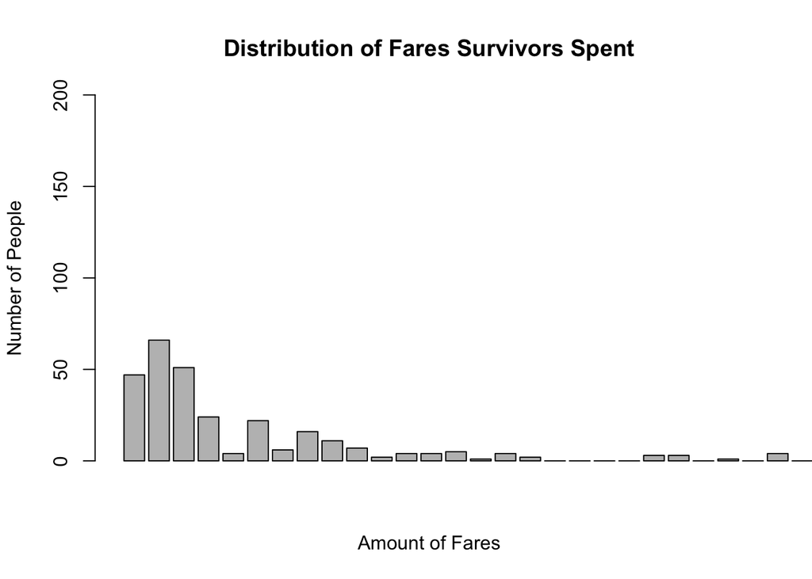

```r
barplot(vectorOfTimesOfDistributionOfSurvivor, xlim = c(0, 30), ylim = c(0, 200), main = "Distribution of Fares Survivors Spent", xlab = "Amount of Fares", ylab = "Number of People")
```

The sixth variable is Fare, which means the fares each passenger need to pay. After we ran the codes above and see the histogram, we could find that the passengers whose fares were around 10~30 could survive more possibly relatively. The histograms of the distribution of the fares were shown above.

##### 9. Cabin

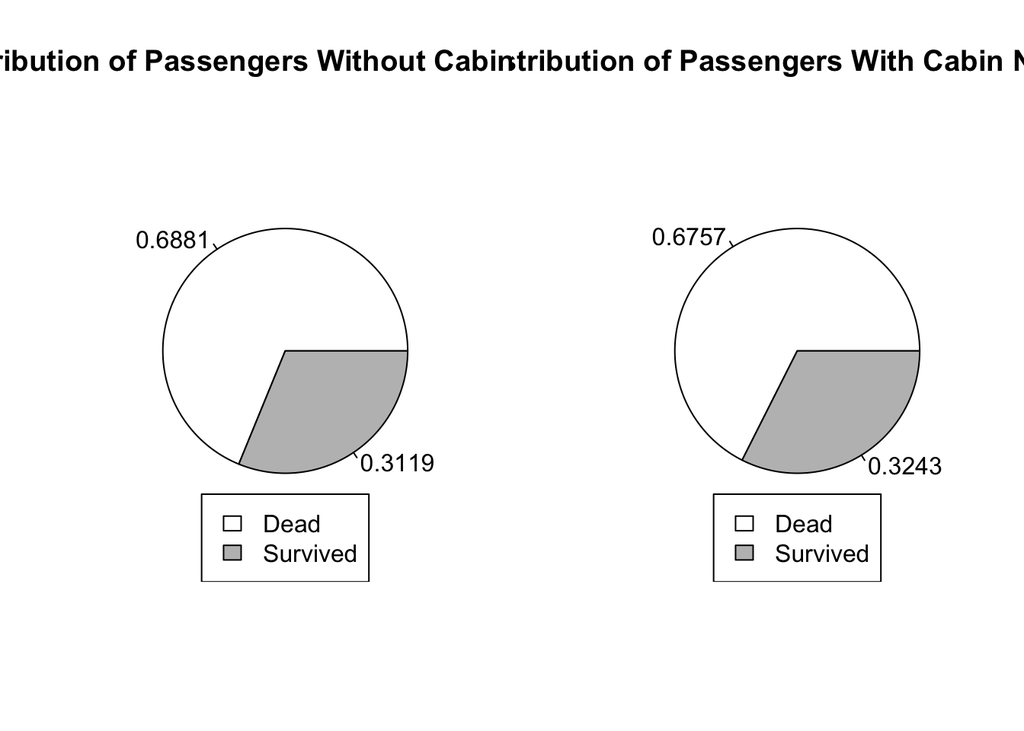

```r
# Cabin
tableOfNumberOfSurvivedAndCabin<- table(rawDataOfTitanicWithoutNull$Cabin, rawDataOfTitanicWithoutNull$Survived)
PercentageOfSurvivedRateWithoutCabinNumber <- round(tableOfNumberOfSurvivedAndCabin[1, 1]/(tableOfNumberOfSurvivedAndCabin[1, 1] + tableOfNumberOfSurvivedAndCabin[1, 2]), 4)
PercentageOfDyingRateWithoutCabinNumber <- 1 - PercentageOfSurvivedRateWithoutCabinNumber

par(mfrow = c(1, 2))
pie(c(tableOfNumberOfSurvivedAndCabin[1, 1], tableOfNumberOfSurvivedAndCabin[1, 2]), col = c("white", "gray"), labels = c(PercentageOfSurvivedRateWithoutCabinNumber, PercentageOfDyingRateWithoutCabinNumber), main = "Distribution of Passengers Without Cabin Number")
legend("bottom", c("Dead", "Survived"), fill = colorOfPieChart)

NumberOfDyingRateWithCabinNumber = 0
NumberOfSurvivedRateWithCabinNumber = 0
for (i in 2:nrow(tableOfNumberOfSurvivedAndCabin)) {
  NumberOfDyingRateWithCabinNumber = tableOfNumberOfSurvivedAndCabin[i, 1] + NumberOfDyingRateWithCabinNumber
  NumberOfSurvivedRateWithCabinNumber = tableOfNumberOfSurvivedAndCabin[i, 2] + NumberOfSurvivedRateWithCabinNumber
}

PercentageOfSurvivedRateWithCabinNumber <- round(NumberOfSurvivedRateWithCabinNumber / (NumberOfSurvivedRateWithCabinNumber + NumberOfDyingRateWithCabinNumber), 4)
PercentageOfDyingRateWithCabinNumber <- 1 - PercentageOfSurvivedRateWithCabinNumber

pie(c(NumberOfSurvivedRateWithCabinNumber, NumberOfDyingRateWithCabinNumber), col = c("white", "gray"), labels = c(PercentageOfSurvivedRateWithCabinNumber, PercentageOfDyingRateWithCabinNumber), main = "Distribution of Passengers With Cabin Number")
legend("bottom", c("Dead", "Survived"), fill = colorOfPieChart)
```

The seventh variable is Cabin, which means the cabin number of each passenger. After we ran the codes above and checked the pie charts, we could find that the cabin number almost would not influence the survival of passenger. The pie charts of the distribution of passengers’ cabin number were shown above.

##### 10. Embark

```r
# Embark
par(mfrow = c(1, 1))
tableOfNumberOfSurvivedAndEmbark <- table(rawDataOfTitanicWithoutNull$Survived, rawDataOfTitanicWithoutNull$Embarked)
tableOfNumberOfSurvivedAndEmbark
```

```
##
##           C   Q   S
##   0   0  51  20 353
##   1   2  79   8 201
```

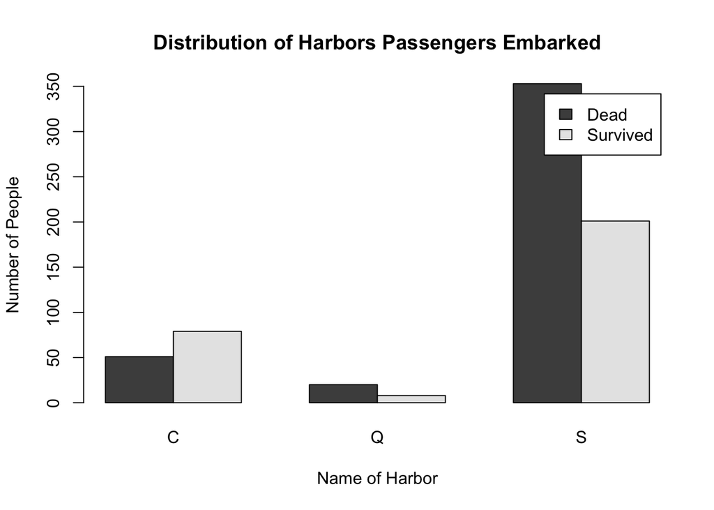

```r
barplot(tableOfNumberOfSurvivedAndEmbark[, 2:4], beside = T, main = "Distribution of Harbors Passengers Embarked", legend.text = c("Dead", "Survived"), xlab = "Name of Harbor", ylab = "Number of People")
```

The eighth variable is Embark, which means the harbor passengers chose to start their journey. After we ran the codes above and checked the bar plot, we could find that the passengers who embark the Titanic from C harbor could survive more possibly. The bar plot of the distribution of harbors was shown above.

Actually, I have not analyzed some variables yet. However, I reckon that I have analyzed almost all of the variables, I still could use these variables to do further calculation and estimation. Therefore, I would end my analysis of each variable and go on to the next part.

### Prediction

##### 1. Linear-model (unchecked)

```r
# Linear-Regression
LinearRegressionModel <- lm(Survived~Pclass+Sex+Age+SibSp+Parch+Fare+Embarked, data = rawDataOfTitanicWithoutNull)
summary(LinearRegressionModel)
```

```
##
## Call:
## lm(formula = Survived ~ Pclass + Sex + Age + SibSp + Parch +
##     Fare + Embarked, data = rawDataOfTitanicWithoutNull)
##
## Residuals:
##      Min       1Q   Median       3Q      Max
## -1.09344 -0.22857 -0.06788  0.22815  0.99815
##
## Coefficients:
##               Estimate Std. Error t value Pr(>|t|)
## (Intercept)  1.4919161  0.2813984   5.302 1.54e-07 ***
## Pclass      -0.1873163  0.0228871  -8.184 1.28e-15 ***
## Sexmale     -0.4854369  0.0315205 -15.401  < 2e-16 ***
## Age         -0.0064061  0.0011324  -5.657 2.24e-08 ***
## SibSp       -0.0507454  0.0174357  -2.910  0.00372 **
## Parch       -0.0106791  0.0190483  -0.561  0.57523
## Fare         0.0001963  0.0003468   0.566  0.57162
## EmbarkedC   -0.0895853  0.2735887  -0.327  0.74343
## EmbarkedQ   -0.1883890  0.2822174  -0.668  0.50465
## EmbarkedS   -0.1559910  0.2728347  -0.572  0.56768
## ---
## Signif. codes:  0 '***' 0.001 '**' 0.01 '*' 0.05 '.' 0.1 ' ' 1
##
## Residual standard error: 0.382 on 704 degrees of freedom
## Multiple R-squared:  0.4034, Adjusted R-squared:  0.3958
## F-statistic:  52.9 on 9 and 704 DF,  p-value: < 2.2e-16
```

After I examined the variables, I want to use these variables to estimation. Linear-model is the easist way to do this work, so I want to use it. First of all, I need to choose variables I want to put into the model. Admittedly, I examined eight variables above, but it seems that one of it did not influence the survival of passengers. Hence, I ignore that variable which is Cabin. Afterwards, I ran the codes to build the model and saw its summary, the codes and the result concerning this first model were shown above.

Notwithstanding, I used seven variables to build the model, some variables were not significant. Thus, I excluded three variables which involved Parch, Fare and Embarked to build another linear-model, and the codes & result concerning this second model were shown below.

```r
modifiedLinearRegressionModel <- lm(Survived~Pclass+Sex+Age+SibSp, data = rawDataOfTitanicWithoutNull)
summary(modifiedLinearRegressionModel)
```

```
##
## Call:
## lm(formula = Survived ~ Pclass + Sex + Age + SibSp, data = rawDataOfTitanicWithoutNull)
##
## Residuals:
##      Min       1Q   Median       3Q      Max
## -1.12371 -0.23934 -0.06484  0.22579  1.00073
##
## Coefficients:
##              Estimate Std. Error t value Pr(>|t|)
## (Intercept)  1.396606   0.065609  21.287  < 2e-16 ***
## Pclass      -0.205267   0.018769 -10.937  < 2e-16 ***
## Sexmale     -0.486489   0.030527 -15.937  < 2e-16 ***
## Age         -0.006557   0.001123  -5.839 8.01e-09 ***
## SibSp       -0.054517   0.016230  -3.359 0.000824 ***
## ---
## Signif. codes:  0 '***' 0.001 '**' 0.01 '*' 0.05 '.' 0.1 ' ' 1
##
## Residual standard error: 0.3818 on 709 degrees of freedom
## Multiple R-squared:  0.3997, Adjusted R-squared:  0.3963
## F-statistic:   118 on 4 and 709 DF,  p-value: < 2.2e-16
```

##### 2. Prediction

```r
# Prediction
rawTestDataOfTitanic<- read.csv("/Users/Lizhengen/Documents/GitHub/R-Practice/Data of Titanic/test.csv")
ResultOfTestDataOfTitanic<- read.csv("/Users/Lizhengen/Documents/GitHub/R-Practice/Data of Titanic/gender_submission.csv")
complete.cases(rawTestDataOfTitanic)

rawTestDataOfTitanic[, 12] <- ResultOfTestDataOfTitanic[, 2]
rawTestDataOfTitanicWithoutNull <- na.omit(rawTestDataOfTitanic)
predict(modifiedLinearRegressionModel, rawTestDataOfTitanicWithoutNull)
```

After I built the linear-model, I want to import another data to test the accuracy of this model. So, I ran the codes above to do it. I found that some of these data are null, so I used similar way to exclude the null data. And then, I use the same way to do the prediction. Unfortunately, it is resonable that the result of prediction should be between 0 and 1, but I found that some of the result is over 1, and some of it is negative. I reckon that this the property of dependent variable contribute to this result, the fact is that the dependent variable is dummy, I should use logistic model to do the prediction instead of normal linear-model. Therefore, I used another way to do the prediction in the next step.

##### 3. Generalized Linear Regression Model & Prediction

```r
# Generalized Linear Regression Model & Prediction
GLMModel <- glm(Survived~Pclass+Sex+Age+SibSp, family = binomial(link = "probit"), data = rawDataOfTitanicWithoutNull)
summary(GLMModel)
```

```
##
## Call:
## glm(formula = Survived ~ Pclass + Sex + Age + SibSp, family = binomial(link = "probit"),
##     data = rawDataOfTitanicWithoutNull)
##
## Deviance Residuals:
##     Min       1Q   Median       3Q      Max
## -2.9135  -0.6676  -0.3787   0.6363   2.4798
##
## Coefficients:
##              Estimate Std. Error z value Pr(>|z|)
## (Intercept)  3.200713   0.295353  10.837  < 2e-16 ***
## Pclass      -0.740605   0.077653  -9.537  < 2e-16 ***
## Sexmale     -1.542940   0.119117 -12.953  < 2e-16 ***
## Age         -0.024863   0.004604  -5.400 6.65e-08 ***
## SibSp       -0.222670   0.068610  -3.245  0.00117 **
## ---
## Signif. codes:  0 '***' 0.001 '**' 0.01 '*' 0.05 '.' 0.1 ' ' 1
##
## (Dispersion parameter for binomial family taken to be 1)
##
##     Null deviance: 964.52  on 713  degrees of freedom
## Residual deviance: 638.78  on 709  degrees of freedom
## AIC: 648.78
##
## Number of Fisher Scoring iterations: 5
```

I considered that I could use generalized linear regression model to predict the survival of passengers instead. Hence, I ran the codes above to build the model, and the summary of this model was shown above.

```r
predictionOfGLM <- predict(GLMModel, rawTestDataOfTitanicWithoutNull, type = "response")

for (i in 1:nrow(rawTestDataOfTitanicWithoutNull)) {
  if (predictionOfGLM[i] < 0.5) {
    predictionOfGLM[i] = 0
  } else {
    predictionOfGLM[i] = 1
  }
}
```

Afterward, I use this model to predict the survival of passengers. The result is consecutive, but the resonable result of survival should be discrete. So, I used a loop to round the result to unit digit.

##### 4. Check the Accuracy

```r
# Check the Accuracy
correct = 0
incorrect = 0
accuracy = 0

for (m in 1:nrow(rawTestDataOfTitanicWithoutNull)) {
  if (predictionOfGLM[m] == rawTestDataOfTitanicWithoutNull[m, 12]) {
    correct = correct + 1
  } else {
    incorrect = incorrect + 1
  }
}
accuracy = (correct / (correct + incorrect)) * 100
print(round(accuracy, 2))
```

```
## [1] 93.05
```

### Conclusion

I examined different variables of the raw data first during the process, and I used several different charts to illustrate what I saw. In the middle of the process, I used linear-model to do the prediction. After I found that my way was not proper, I modified my model and predict the result again. In the end, I calculate the accuracy of the result. I applied a lot of knowledge of R through this process, and I consider that the content above has shown what I learned.

However, I think that I still could do something to enahnce my accuracy. For example, I could use another method, which included cointegration, to do the prediction, or I could use other data, such as means, to replace the null data instead of exclusion of null, so that I could obtain more data to do the estimation. I hoped that I could improve this project if I have the chance someday.

This is all of my report, thanks for your reading.

*Copyright © 2018 Li Cheng-En. All Rights Reserved*